# Bond Equity strategies

Objective: Build a strategy that outperforms the traditional 60/40 portfolio

Bond: [TLT](https://www.ishares.com/us/products/239454/ishares-20-year-treasury-bond-etf)  
Equity: [SPY](https://www.ssga.com/us/en/intermediary/etfs/spdr-sp-500-etf-trust-spy)

**Notes**

- Due to my employer's personal dealing policy, I am restricted to trading only once every 30 days, so my strategy uses a rebalancing period of 31 days (additional day to account for approval process).

# Import Packages

```python
import openbb as obb
import pandas as pd
import numpy as np
import statsmodels.api as sm
import sklearn as sk
from typing import Union, List, Tuple, Dict, Callable
import datetime as dt
import calendar
import plotly
import plotly.express as px
import plotly.io as pio
import plotly.offline as pyo
pyo.init_notebook_mode(connected = True)
pio.renderers.default = "plotly_mimetype+jupyterlab"
import math
import os
import arch
from Backtest import Backtest
import scipy as sci
```

```python
pio.renderers.default = "plotly_mimetype+jupyterlab"
```

## Helpers

```python
def show_full_df(data: pd.DataFrame) -> None:
    with pd.option_context('display.max_rows', None, 'display.max_columns', None):
        display(data)
```

# Benchmark - Buy SPY

```python
# Import data from OpenBB
start: dt.date = dt.date(year= 2000,month= 1, day=1)
end: dt.date = dt.date(year= 2025,month= 1, day=1)

SPY_raw: pd.DataFrame = obb.obb.equity.price.historical(symbol= "SPY", start_date= start, end_date = end).to_df()
SPY: pd.DataFrame = SPY_raw[["close","volume"]].rename({"close":"SPY"}, axis = 1)
```

```python
def buy_and_hold_func(tick: dt.date,securities: List = ["SPY"], data= SPY, lookback = 30) -> bool:
    return (1,{"Add_data":{}})
```

```python
buy_and_hold: Backtest = Backtest(name= "Buy and hold", data = SPY)
```

```python
buy_and_hold.securities = ["SPY"]
buy_and_hold.assign_rebal_attr(day_of_rebal = 1, interval = "quarter")
buy_and_hold.assign_signals(trading_signal= buy_and_hold_func)
buy_and_hold.lookback_window = 15
```

```python
benchmark: pd.DataFrame = buy_and_hold.calculate()
```

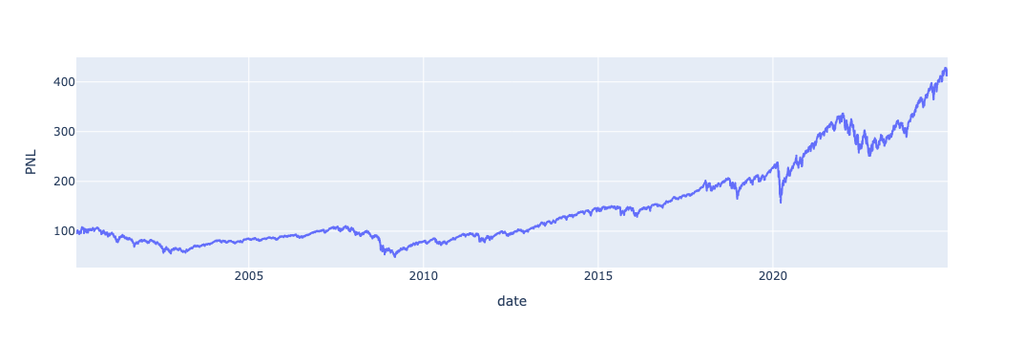

```python
buy_and_hold.plot()
```

```python
buy_and_hold.stats
```

|  | Returns | Volatility | Sharpe |
| --- | --- | --- | --- |
| Results | 0.085997 | 0.19379 | 0.443765 |

```python
# Function for strategy comparison
def outperformance(strategy: Backtest, benchmark: Backtest = buy_and_hold, measure = "Sharpe"):
    try:
        flag: int = 1
        if measure == "Volatility":
            flag: int = -1
        out_performance = float((benchmark.stats[measure] - strategy.stats[measure]).iloc[0])*-1 # I get a strange FutureWarning error if I do this the other way around
        print(f"Outperformance ({measure}): %.3f" %(out_performance*flag))
    except:
        print("Make sure Benchmark strategy has been run")
```

# Import data

```python
TLT_raw: pd.DataFrame = obb.obb.equity.price.historical(symbol= "TLT", start_date= start, end_date = end).to_df()
```

```python
TLT_SPY = SPY.merge(TLT_raw.rename({"close":"TLT"}, axis = 1).TLT, left_index=True, right_index=True)
TLT_SPY.drop("volume", axis = 1, inplace = True)
```

# Visualisation and initial analysis

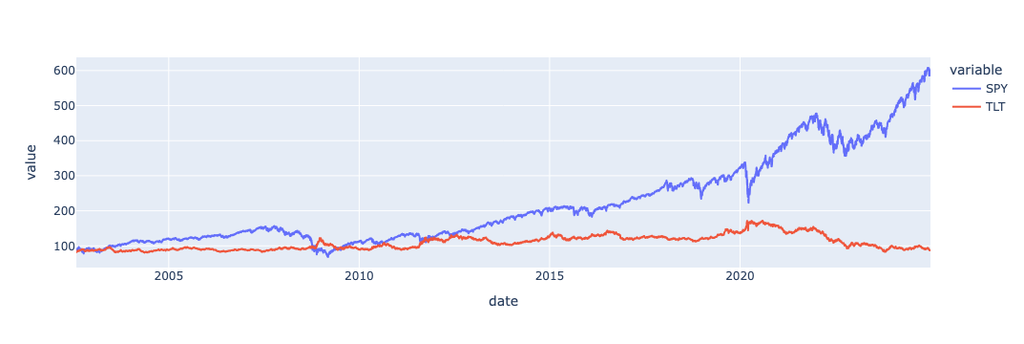

```python
fig1 = px.line(TLT_SPY, x = TLT_SPY.index, y = ["SPY", "TLT"])
fig1.update_layout(autosize = True)
fig1.show()
```

```python
# Calculate log returns for TLT and SPY
TLT_SPY_logret = (np.log(TLT_SPY) - np.log(TLT_SPY.shift(1))).dropna(how = "any")
```

```python
# Calculate correlation of TLT and SPY log returns
TLT_SPY_logret.corr()
```

|  | SPY | TLT |
| --- | --- | --- |
| SPY | 1.00000 | -0.32641 |
| TLT | -0.32641 | 1.00000 |

```python
pio.renderers
```

```
Renderers configuration
-----------------------
    Default renderer: 'plotly_mimetype+jupyterlab'
    Available renderers:
        ['plotly_mimetype', 'jupyterlab', 'nteract', 'vscode',
         'notebook', 'notebook_connected', 'kaggle', 'azure', 'colab',
         'cocalc', 'databricks', 'json', 'png', 'jpeg', 'jpg', 'svg',
         'pdf', 'browser', 'firefox', 'chrome', 'chromium', 'iframe',
         'iframe_connected', 'sphinx_gallery', 'sphinx_gallery_png']
```

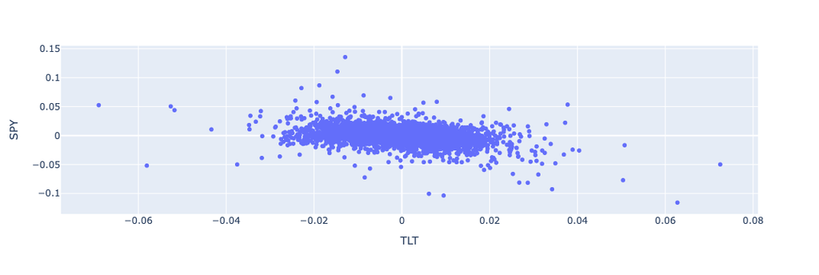

```python
# Plot scatter of log returns
fig2 = px.scatter(TLT_SPY_logret, x = "TLT", y = "SPY")
fig2.update_layout(autosize = True)
fig2.show()
```

```python
# Simple regression model of log returns
reg0_model = sm.regression.linear_model.OLS(TLT_SPY_logret.SPY, TLT_SPY_logret.TLT)
reg0_results = reg0_model.fit()
reg0_results.summary()
```

OLS Regression Results

| Dep. Variable: | SPY | R-squared (uncentered): | 0.106 |
| --- | --- | --- | --- |
| Model: | OLS | Adj. R-squared (uncentered): | 0.106 |
| Method: | Least Squares | F-statistic: | 672.2 |
| Date: | Wed, 02 Apr 2025 | Prob (F-statistic): | 4.08e-140 |
| Time: | 20:46:19 | Log-Likelihood: | 17300. |
| No. Observations: | 5644 | AIC: | -3.460e+04 |
| Df Residuals: | 5643 | BIC: | -3.459e+04 |
| Df Model: | 1 |  |  |
| Covariance Type: | nonrobust |  |  |

|  | coef | std err | t | P>\|t\| | [0.025 | 0.975] |
| --- | --- | --- | --- | --- | --- | --- |
| TLT | -0.4260 | 0.016 | -25.926 | 0.000 | -0.458 | -0.394 |

| Omnibus: | 1152.497 | Durbin-Watson: | 2.147 |
| --- | --- | --- | --- |
| Prob(Omnibus): | 0.000 | Jarque-Bera (JB): | 35251.501 |
| Skew: | -0.225 | Prob(JB): | 0.00 |
| Kurtosis: | 15.235 | Cond. No. | 1.00 |

Notes:  
[1] R² is computed without centering (uncentered) since the model does not contain a constant.  
[2] Standard Errors assume that the covariance matrix of the errors is correctly specified.

**Comment**

- Whilst the T-statistic is very high, the R<sup>2</sup> is very low (would expect this given how naive it is)

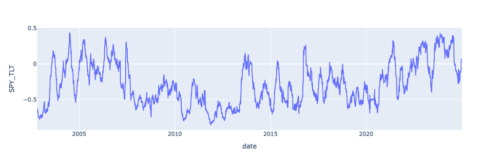

```python
# Rolling correlation between log returns
rolling_corr = TLT_SPY_logret[["SPY","TLT"]].rolling(60).corr().unstack().iloc[:,1].dropna()
rolling_corr.name = "SPY_TLT"

fig3 = px.line(rolling_corr, x = rolling_corr.index, y = "SPY_TLT")
fig3.update_layout(autosize = True)
fig3.show()
```

# Strategies

```python
# Split data in half for training
train_TLT_SPY = TLT_SPY.iloc[:int(len(TLT_SPY)/2)]
```

## Simple 60/40 portfolio

```python
def TLT_SPY_0(tick, securities: List = ["SPY","TLT"], data = train_TLT_SPY, lookback = 180) -> Tuple[int, Dict]:
    index_loc_tic: int = data.index.get_loc(tick)
    lb_window = data.iloc[index_loc_tic-lookback:index_loc_tic]

    sig: tuple = (0.6,0.4)


    return (sig, {"add_data":{}})
```

```python
TLT_SPY0: Backtest = Backtest(name= "Basic 60/40", data = train_TLT_SPY)
```

```python
TLT_SPY0.securities = ["SPY", "TLT"]
TLT_SPY0.assign_rebal_attr(fixed_ticks=31)
TLT_SPY0.assign_signals(trading_signal= TLT_SPY_0)
TLT_SPY0.lookback_window = 60
```

```python
TLT_SPY0.calculate()
```

| date | SPY | TLT | PNL | SPY holdings | TLT holdings | SPY weights | TLT weights | Costs | Add_data |
| --- | --- | --- | --- | --- | --- | --- | --- | --- | --- |
| 2002-10-23 | 90.199997 | 84.330002 | 100.000000 | 0.665188 | 0.474327 | 0.6 | 0.4 | NaN | [{'add_data': {}}] |
| 2002-10-24 | 88.360001 | 85.070000 | 99.127057 | 0.665188 | 0.474327 | 0.6 | 0.4 | 0.0 | NaN |
| 2002-10-25 | 90.199997 | 85.379997 | 100.498041 | 0.665188 | 0.474327 | 0.6 | 0.4 | 0.0 | NaN |
| 2002-10-28 | 89.610001 | 85.260002 | 100.048666 | 0.665188 | 0.474327 | 0.6 | 0.4 | 0.0 | NaN |
| 2002-10-29 | 88.570000 | 86.370003 | 99.883372 | 0.665188 | 0.474327 | 0.6 | 0.4 | 0.0 | NaN |
| ... | ... | ... | ... | ... | ... | ... | ... | ... | ... |
| 2013-10-07 | 167.429993 | 106.139999 | 172.603651 | 0.617619 | 0.652131 | 0.6 | 0.4 | 0.0 | NaN |
| 2013-10-08 | 165.479996 | 106.169998 | 171.418859 | 0.617619 | 0.652131 | 0.6 | 0.4 | 0.0 | NaN |
| 2013-10-09 | 165.600006 | 105.320000 | 170.938669 | 0.621533 | 0.645828 | 0.6 | 0.4 | 0.0 | [{'add_data': {}, 'rebal_data': (True, True, N... |
| 2013-10-10 | 169.169998 | 105.489998 | 173.267327 | 0.621533 | 0.645828 | 0.6 | 0.4 | 0.0 | NaN |
| 2013-10-11 | 170.259995 | 105.459999 | 173.925422 | 0.621533 | 0.645828 | 0.6 | 0.4 | 0.0 | NaN |

2762 rows × 9 columns

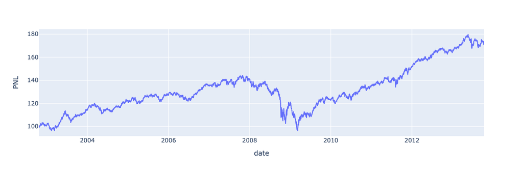

```python
TLT_SPY0.plot()
```

```python
TLT_SPY0.stats
```

|  | Returns | Volatility | Sharpe |
| --- | --- | --- | --- |
| Results | 0.075881 | 0.108423 | 0.699859 |

```python
outperformance(TLT_SPY0)
```

```
Outperformance (Sharpe): 0.256
```

```python
outperformance(TLT_SPY0, measure = "Returns")
```

```
Outperformance (Returns): -0.010
```

```python
outperformance(TLT_SPY0, measure = "Volatility")
```

```
Outperformance (Volatility): 0.085
```

**Comments**

## Dynamic weights - Simple regression

Idea: Use a simple regression model to inform the weights

```python
sm.regression.linear_model.RegressionModel
```

```
statsmodels.regression.linear_model.RegressionModel
```

```python
def TLT_SPY_1(tick, securities: List = ["SPY","TLT"], data = train_TLT_SPY, lookback = 180) -> Tuple[int, Dict]:
    index_loc_tic: int = data.index.get_loc(tick)
    lb_window = data.iloc[index_loc_tic-lookback:index_loc_tic]

    lb_log_ret = (np.log(lb_window)-np.log(lb_window.shift(1))).dropna(how = "any")

    reg_model = sm.regression.linear_model.OLS(lb_log_ret.SPY, lb_log_ret.TLT)
    reg_results = reg_model.fit()

    TLT_coef: float = reg_results.params.iloc[0]

    SPY_w = 1/(1+abs(TLT_coef))
    TLT_w = 1 - SPY_w

    sig: tuple = (SPY_w,TLT_w)

    return (sig, {"add_data":{"beta": TLT_coef}})
```

```python
TLT_SPY1: Backtest = Backtest(name= "SPY TLT dynamic weights", data = train_TLT_SPY)

TLT_SPY1.securities = ["SPY", "TLT"]
TLT_SPY1.assign_rebal_attr(fixed_ticks=31)
TLT_SPY1.assign_signals(trading_signal= TLT_SPY_1)
TLT_SPY1.lookback_window = 60
```

```python
TLT_SPY1.calculate()
```

| date | SPY | TLT | PNL | SPY holdings | TLT holdings | SPY weights | TLT weights | Costs | Add_data |
| --- | --- | --- | --- | --- | --- | --- | --- | --- | --- |
| 2002-10-23 | 90.199997 | 84.330002 | 100.000000 | 0.406302 | 0.751234 | 0.366484 | 0.633516 | NaN | [{'add_data': {'beta': -1.7286291645719383}}] |
| 2002-10-24 | 88.360001 | 85.070000 | 99.808317 | 0.406302 | 0.751234 | 0.366484 | 0.633516 | 0.0 | NaN |
| 2002-10-25 | 90.199997 | 85.379997 | 100.788792 | 0.406302 | 0.751234 | 0.366484 | 0.633516 | 0.0 | NaN |
| 2002-10-28 | 89.610001 | 85.260002 | 100.458931 | 0.406302 | 0.751234 | 0.366484 | 0.633516 | 0.0 | NaN |
| 2002-10-29 | 88.570000 | 86.370003 | 100.870247 | 0.406302 | 0.751234 | 0.366484 | 0.633516 | 0.0 | NaN |
| ... | ... | ... | ... | ... | ... | ... | ... | ... | ... |
| 2013-10-07 | 167.429993 | 106.139999 | 216.137248 | 1.200765 | 0.141439 | 0.930777 | 0.069223 | 0.0 | NaN |
| 2013-10-08 | 165.479996 | 106.169998 | 213.800003 | 1.200765 | 0.141439 | 0.930777 | 0.069223 | 0.0 | NaN |
| 2013-10-09 | 165.600006 | 105.320000 | 213.823885 | 1.232830 | 0.092223 | 0.954203 | 0.045797 | 0.0 | [{'add_data': {'beta': -0.047994570132664394},... |
| 2013-10-10 | 169.169998 | 105.489998 | 218.240756 | 1.232830 | 0.092223 | 0.954203 | 0.045797 | 0.0 | NaN |
| 2013-10-11 | 170.259995 | 105.459999 | 219.581769 | 1.232830 | 0.092223 | 0.954203 | 0.045797 | 0.0 | NaN |

2762 rows × 9 columns

```python
TLT_SPY1.output.describe()
```

|  | SPY | TLT | PNL | SPY holdings | TLT holdings | SPY weights | TLT weights | Costs |
| --- | --- | --- | --- | --- | --- | --- | --- | --- |
| count | 2762.000000 | 2762.000000 | 2762.000000 | 2762.000000 | 2762.000000 | 2762.000000 | 2762.000000 | 2761.0 |
| mean | 122.957346 | 96.676846 | 150.588186 | 0.840132 | 0.466456 | 0.694046 | 0.305954 | 0.0 |
| std | 20.538104 | 12.043123 | 31.747038 | 0.179354 | 0.246811 | 0.168003 | 0.168003 | 0.0 |
| min | 68.110001 | 80.650002 | 98.577690 | 0.406302 | 0.019623 | 0.360638 | 0.014229 | 0.0 |
| 25% | 110.202497 | 88.412502 | 126.983783 | 0.719588 | 0.219667 | 0.568977 | 0.157821 | 0.0 |
| 50% | 123.155003 | 92.115002 | 146.033318 | 0.861508 | 0.507014 | 0.687659 | 0.312341 | 0.0 |
| 75% | 137.047501 | 101.902502 | 172.232852 | 0.967784 | 0.690264 | 0.842179 | 0.431023 | 0.0 |
| max | 173.050003 | 132.160004 | 222.722903 | 1.232830 | 0.851442 | 0.985771 | 0.639362 | 0.0 |

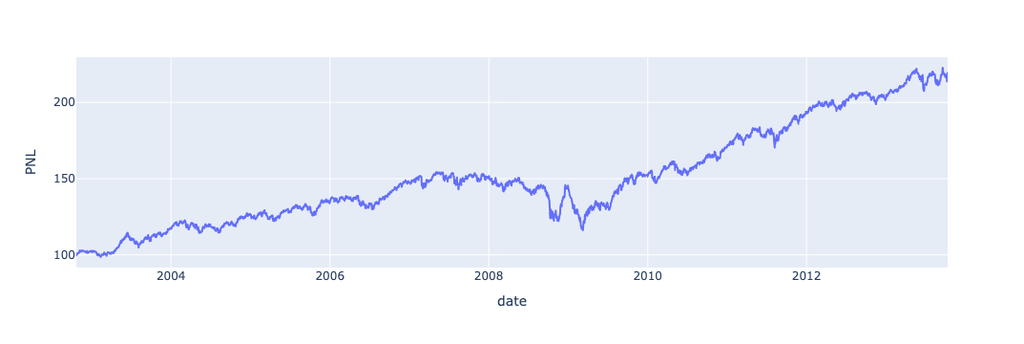

```python
TLT_SPY1.plot()
```

```python
TLT_SPY1.stats
```

|  | Returns | Volatility | Sharpe |
| --- | --- | --- | --- |
| Results | 0.109538 | 0.104603 | 1.047181 |

```python
outperformance(TLT_SPY1)
```

```
Outperformance (Sharpe): 0.603
```

```python
outperformance(TLT_SPY1, benchmark = TLT_SPY0)
```

```
Outperformance (Sharpe): 0.347
```

```python
outperformance(TLT_SPY1, measure = "Returns")
```

```
Outperformance (Returns): 0.024
```

**Comments**

- Significant improvement in Sharpe vs 60/40
- Still seeing sluggish performance between 2007 and 2009
- Interestingly, returns went up vs Buy-and-hold strategy

## Controlling for Volatility - adding VIX

Idea: Volatility is a key variable that dictates the relationship between bonds and stocks - stocks and bonds move together (usually down) during periods of high volatility. The most naive way to do this is to incorporate VIX into the simple regression approach above.

```python
# Import data from OpenBB
VIX_raw: pd.DataFrame = obb.obb.equity.price.historical(symbol= "^VIX", start_date= start, end_date= end).to_df()
VIX = VIX_raw[["close"]].rename({"close":"VIX"}, axis = 1)
```

```python
# TSV for "TLT, SPY, VIX"
TSV = TLT_SPY.merge(VIX, left_index= True, right_index = True)
```

```python
# Calculate log returns
TSV_log_ret = (np.log(TSV) - np.log(TSV.shift(1))).dropna(how = "any")
```

```python
reg2_model = sm.regression.linear_model.OLS(TSV_log_ret.SPY, TSV_log_ret[["TLT","VIX"]])
reg2_results = reg2_model.fit()
reg2_results.summary()
```

OLS Regression Results

| Dep. Variable: | SPY | R-squared (uncentered): | 0.548 |
| --- | --- | --- | --- |
| Model: | OLS | Adj. R-squared (uncentered): | 0.548 |
| Method: | Least Squares | F-statistic: | 3422. |
| Date: | Wed, 02 Apr 2025 | Prob (F-statistic): | 0.00 |
| Time: | 20:43:07 | Log-Likelihood: | 19224. |
| No. Observations: | 5644 | AIC: | -3.844e+04 |
| Df Residuals: | 5642 | BIC: | -3.843e+04 |
| Df Model: | 2 |  |  |
| Covariance Type: | nonrobust |  |  |

|  | coef | std err | t | P>\|t\| | [0.025 | 0.975] |
| --- | --- | --- | --- | --- | --- | --- |
| TLT | -0.2033 | 0.012 | -16.848 | 0.000 | -0.227 | -0.180 |
| VIX | -0.1128 | 0.002 | -74.260 | 0.000 | -0.116 | -0.110 |

| Omnibus: | 1516.638 | Durbin-Watson: | 2.147 |
| --- | --- | --- | --- |
| Prob(Omnibus): | 0.000 | Jarque-Bera (JB): | 92246.409 |
| Skew: | 0.393 | Prob(JB): | 0.00 |
| Kurtosis: | 22.790 | Cond. No. | 8.21 |

Notes:  
[1] R² is computed without centering (uncentered) since the model does not contain a constant.  
[2] Standard Errors assume that the covariance matrix of the errors is correctly specified.

Comment

- The stand-out observation here is the improvement in R<sup>2</sup>

```python
fig4 = px.scatter_3d(TSV_log_ret, x = "SPY", y = "VIX", z = "TLT").update_traces(marker = dict(size = 1))
fig4.update_layout(autosize = True, height = 450)
fig4.show()
```

[output not shown]

**Comments**

- Clear negative relationship between VIX log returns and SPY
- Conscious that the absolute level of the VIX is important but changes in the VIX are also a key thing to consider

```python
# Split data in half for training
train_TSV = TSV.iloc[:int(len(TSV)/2)]
```

```python
def TLT_SPY_2(tick, securities: List = ["SPY","TLT"], data = train_TSV, lookback = 180) -> Tuple[int, Dict]:
    index_loc_tic: int = data.index.get_loc(tick)
    lb_window = data.iloc[index_loc_tic-lookback:index_loc_tic]

    lb_log_ret = (np.log(lb_window)-np.log(lb_window.shift(1))).dropna(how = "any")

    reg_model = sm.regression.linear_model.OLS(lb_log_ret.SPY, lb_log_ret[["TLT","VIX"]])
    reg_results = reg_model.fit()

    TLT_coef: float = reg_results.params.loc["TLT"]

    SPY_w = 1/(1+abs(TLT_coef))
    TLT_w = 1 - SPY_w

    sig: tuple = (SPY_w,TLT_w)

    return (sig, {"add_data":{"beta": TLT_coef}})
```

```python
TLT_SPY2: Backtest = Backtest(name= "SPY TLT VIX dynamic weights", data = train_TSV)
TLT_SPY2.securities = ["SPY", "TLT"]
TLT_SPY2.assign_rebal_attr(fixed_ticks=31)
TLT_SPY2.assign_signals(trading_signal= TLT_SPY_2)
TLT_SPY2.lookback_window = 60
```

```python
TLT_SPY2.calculate()
```

| date | SPY | TLT | VIX | PNL | SPY holdings | TLT holdings | SPY weights | TLT weights | Costs | Add_data |
| --- | --- | --- | --- | --- | --- | --- | --- | --- | --- | --- |
| 2002-10-23 | 90.199997 | 84.330002 | 33.200001 | 100.000000 | 0.673078 | 0.465888 | 0.607117 | 0.392883 | NaN | [{'add_data': {'beta': -0.6471301288792514}}] |
| 2002-10-24 | 88.360001 | 85.070000 | 34.029999 | 99.106295 | 0.673078 | 0.465888 | 0.607117 | 0.392883 | 0.0 | NaN |
| 2002-10-25 | 90.199997 | 85.379997 | 30.000000 | 100.489180 | 0.673078 | 0.465888 | 0.607117 | 0.392883 | 0.0 | NaN |
| 2002-10-28 | 89.610001 | 85.260002 | 31.070000 | 100.036162 | 0.673078 | 0.465888 | 0.607117 | 0.392883 | 0.0 | NaN |
| 2002-10-29 | 88.570000 | 86.370003 | 32.270000 | 99.853296 | 0.673078 | 0.465888 | 0.607117 | 0.392883 | 0.0 | NaN |
| ... | ... | ... | ... | ... | ... | ... | ... | ... | ... | ... |
| 2013-10-07 | 167.429993 | 106.139999 | 19.410000 | 201.114835 | 1.178912 | 0.035127 | 0.981534 | 0.018466 | 0.0 | NaN |
| 2013-10-08 | 165.479996 | 106.169998 | 20.340000 | 198.817015 | 1.178912 | 0.035127 | 0.981534 | 0.018466 | 0.0 | NaN |
| 2013-10-09 | 165.600006 | 105.320000 | 19.600000 | 198.928639 | 1.103492 | 0.152690 | 0.918462 | 0.081538 | 0.0 | [{'add_data': {'beta': -0.08877670441963324}, ... |
| 2013-10-10 | 169.169998 | 105.489998 | 16.480000 | 202.894054 | 1.103492 | 0.152690 | 0.918462 | 0.081538 | 0.0 | NaN |
| 2013-10-11 | 170.259995 | 105.459999 | 15.720000 | 204.092276 | 1.103492 | 0.152690 | 0.918462 | 0.081538 | 0.0 | NaN |

2762 rows × 10 columns

```python
TLT_SPY2.output.describe()
```

|  | SPY | TLT | VIX | PNL | SPY holdings | TLT holdings | SPY weights | TLT weights | Costs |
| --- | --- | --- | --- | --- | --- | --- | --- | --- | --- |
| count | 2762.000000 | 2762.000000 | 2762.000000 | 2762.000000 | 2762.000000 | 2762.000000 | 2762.000000 | 2762.000000 | 2761.0 |
| mean | 122.957346 | 96.676846 | 20.612252 | 143.172725 | 0.961823 | 0.242613 | 0.828027 | 0.171973 | 0.0 |
| std | 20.538104 | 12.043123 | 9.611184 | 25.760202 | 0.130203 | 0.145645 | 0.115827 | 0.115827 | 0.0 |
| min | 68.110001 | 80.650002 | 9.890000 | 92.349993 | 0.517940 | 0.000370 | 0.466025 | 0.000206 | 0.0 |
| 25% | 110.202497 | 88.412502 | 14.280000 | 123.023692 | 0.900262 | 0.142692 | 0.766519 | 0.087643 | 0.0 |
| 50% | 123.155003 | 92.115002 | 17.945001 | 139.980005 | 0.968337 | 0.238153 | 0.831126 | 0.168874 | 0.0 |
| 75% | 137.047501 | 101.902502 | 23.885000 | 160.298494 | 1.029907 | 0.343428 | 0.912357 | 0.233481 | 0.0 |
| max | 173.050003 | 132.160004 | 80.860001 | 207.699934 | 1.242650 | 0.630784 | 0.999794 | 0.533975 | 0.0 |

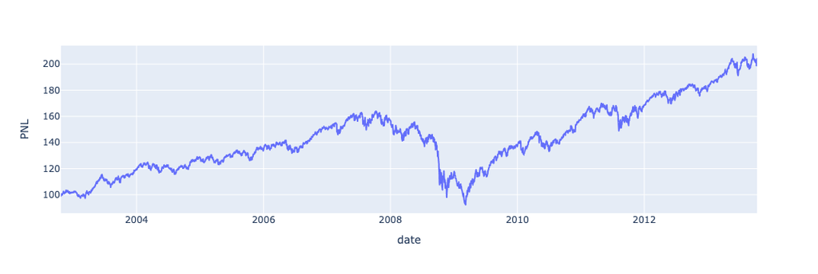

```python
TLT_SPY2.plot()
```

```python
TLT_SPY2.stats
```

|  | Returns | Volatility | Sharpe |
| --- | --- | --- | --- |
| Results | 0.098864 | 0.148952 | 0.663728 |

```python
outperformance(TLT_SPY2)
```

```
Outperformance (Sharpe): 0.220
```

```python
outperformance(TLT_SPY2, benchmark = TLT_SPY1, measure = "Volatility")
```

```
Outperformance (Volatility): -0.044
```

**Comments**

- The underperformance between 2007 and 2009 has returned, bringing pnl down below the inital investment amount
- Although annualised returns are much better (than buy-and-hold and 60/40) - it's interesting to note the significant increase in volatility vs the simple regression approach above

## Using T-statistic instead of regression coefficients

Idea: Shifitng from regression coefficients to T-statistics should structurally increase my TLT allocation where the relationship is statistically stronger. I still think controlling for VIX is appropriate given the rational above.

```python
def TLT_SPY_3(tick, securities: List = ["SPY","TLT"], data = train_TSV, lookback = 180) -> Tuple[int, Dict]:
    index_loc_tic: int = data.index.get_loc(tick)
    lb_window = data.iloc[index_loc_tic-lookback:index_loc_tic]

    lb_log_ret = (np.log(lb_window)-np.log(lb_window.shift(1))).dropna(how = "any")

    reg_model = sm.regression.linear_model.OLS(lb_log_ret.SPY, lb_log_ret[["TLT","VIX"]])
    reg_results = reg_model.fit()

    TLT_coef: float = reg_results.tvalues.loc["TLT"]

    SPY_w = 1/(1+abs(TLT_coef))
    TLT_w = 1 - SPY_w

    sig: tuple = (SPY_w,TLT_w)

    return (sig, {"add_data":{"beta": TLT_coef}})
```

```python
TLT_SPY3: Backtest = Backtest(name= "SPY TLT VIX dynamic weights + T statistics", data = train_TSV)
TLT_SPY3.securities = ["SPY", "TLT"]
TLT_SPY3.assign_rebal_attr(fixed_ticks=31)
TLT_SPY3.assign_signals(trading_signal= TLT_SPY_3)
TLT_SPY3.lookback_window = 60
```

```python
TLT_SPY3.calculate()
```

| date | SPY | TLT | VIX | PNL | SPY holdings | TLT holdings | SPY weights | TLT weights | Costs | Add_data |
| --- | --- | --- | --- | --- | --- | --- | --- | --- | --- | --- |
| 2002-10-23 | 90.199997 | 84.330002 | 33.200001 | 100.000000 | 0.271440 | 0.895484 | 0.244839 | 0.755161 | NaN | [{'add_data': {'beta': -3.084322555846486}}] |
| 2002-10-24 | 88.360001 | 85.070000 | 34.029999 | 100.163208 | 0.271440 | 0.895484 | 0.244839 | 0.755161 | 0.0 | NaN |
| 2002-10-25 | 90.199997 | 85.379997 | 30.000000 | 100.940254 | 0.271440 | 0.895484 | 0.244839 | 0.755161 | 0.0 | NaN |
| 2002-10-28 | 89.610001 | 85.260002 | 31.070000 | 100.672652 | 0.271440 | 0.895484 | 0.244839 | 0.755161 | 0.0 | NaN |
| 2002-10-29 | 88.570000 | 86.370003 | 32.270000 | 101.384341 | 0.271440 | 0.895484 | 0.244839 | 0.755161 | 0.0 | NaN |
| ... | ... | ... | ... | ... | ... | ... | ... | ... | ... | ... |
| 2013-10-07 | 167.429993 | 106.139999 | 19.410000 | 202.422185 | 0.905975 | 0.479018 | 0.749718 | 0.250282 | 0.0 | NaN |
| 2013-10-08 | 165.479996 | 106.169998 | 20.340000 | 200.669907 | 0.905975 | 0.479018 | 0.749718 | 0.250282 | 0.0 | NaN |
| 2013-10-09 | 165.600006 | 105.320000 | 19.600000 | 200.371469 | 0.502791 | 1.106415 | 0.414620 | 0.585380 | 0.0 | [{'add_data': {'beta': -1.4118450315039979}, '... |
| 2013-10-10 | 169.169998 | 105.489998 | 16.480000 | 202.354517 | 0.502791 | 1.106415 | 0.414620 | 0.585380 | 0.0 | NaN |
| 2013-10-11 | 170.259995 | 105.459999 | 15.720000 | 202.869366 | 0.502791 | 1.106415 | 0.414620 | 0.585380 | 0.0 | NaN |

2762 rows × 10 columns

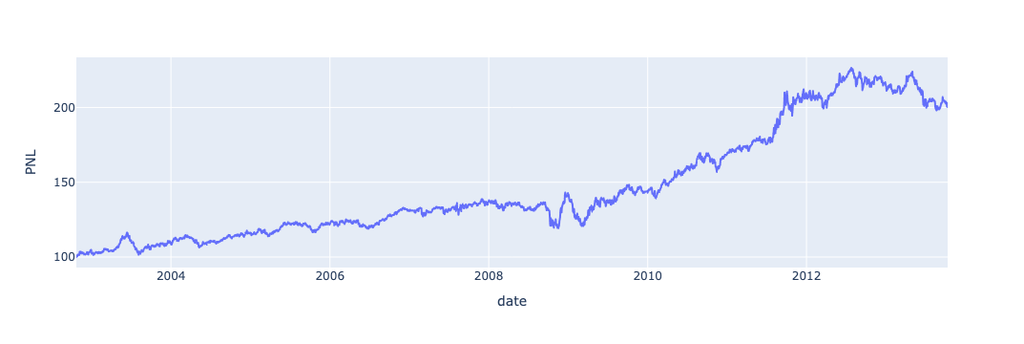

```python
TLT_SPY3.plot()
```

```python
TLT_SPY3.stats
```

|  | Returns | Volatility | Sharpe |
| --- | --- | --- | --- |
| Results | 0.097991 | 0.10574 | 0.926717 |

```python
outperformance(TLT_SPY3)
```

```
Outperformance (Sharpe): 0.483
```

```python
TLT_SPY3.output.describe()
```

|  | SPY | TLT | VIX | PNL | SPY holdings | TLT holdings | SPY weights | TLT weights | Costs |
| --- | --- | --- | --- | --- | --- | --- | --- | --- | --- |
| count | 2762.000000 | 2762.000000 | 2762.000000 | 2762.000000 | 2762.000000 | 2762.000000 | 2762.000000 | 2762.000000 | 2761.0 |
| mean | 122.957346 | 96.676846 | 20.612252 | 146.385920 | 0.447726 | 0.915835 | 0.391050 | 0.608950 | 0.0 |
| std | 20.538104 | 12.043123 | 9.611184 | 36.464030 | 0.236360 | 0.374804 | 0.215471 | 0.215471 | 0.0 |
| min | 68.110001 | 80.650002 | 9.890000 | 100.000000 | 0.130056 | 0.004518 | 0.116754 | 0.002969 | 0.0 |
| 25% | 110.202497 | 88.412502 | 14.280000 | 119.826836 | 0.285172 | 0.683529 | 0.232810 | 0.503300 | 0.0 |
| 50% | 123.155003 | 92.115002 | 17.945001 | 133.278059 | 0.368613 | 0.925587 | 0.331204 | 0.668796 | 0.0 |
| 75% | 137.047501 | 101.902502 | 23.885000 | 170.171382 | 0.492595 | 1.197899 | 0.496700 | 0.767190 | 0.0 |
| max | 173.050003 | 132.160004 | 80.860001 | 226.487050 | 1.225345 | 1.506269 | 0.997031 | 0.883246 | 0.0 |

```python
outperformance(strategy= TLT_SPY3, benchmark=TLT_SPY0)
```

```
Outperformance (Sharpe): 0.227
```

**Comment**

- This approach manages the drawdown between 2007 and 2009 much better
- Slightly lower returns, but I expect this comes from the higher allocation to TLT

### Out of sample performance

```python
TLT_SPY3_OOS: Backtest = Backtest(name= "SPY TLT VIX dynamic weights + T statistics - Out of sample", data = TSV)
TLT_SPY3_OOS.securities = ["SPY", "TLT"]
TLT_SPY3_OOS.assign_rebal_attr(fixed_ticks=31)
TLT_SPY3_OOS.assign_signals(trading_signal= TLT_SPY_3)
TLT_SPY3_OOS.lookback_window = 60
```

```python
TLT_SPY3_OOS.calculate()
```

| date | SPY | TLT | VIX | PNL | SPY holdings | TLT holdings | SPY weights | TLT weights | Costs | Add_data |
| --- | --- | --- | --- | --- | --- | --- | --- | --- | --- | --- |
| 2002-10-23 | 90.199997 | 84.330002 | 33.200001 | 100.000000 | 0.271440 | 0.895484 | 0.244839 | 0.755161 | NaN | [{'add_data': {'beta': -3.084322555846486}}] |
| 2002-10-24 | 88.360001 | 85.070000 | 34.029999 | 100.163208 | 0.271440 | 0.895484 | 0.244839 | 0.755161 | 0.0 | NaN |
| 2002-10-25 | 90.199997 | 85.379997 | 30.000000 | 100.940254 | 0.271440 | 0.895484 | 0.244839 | 0.755161 | 0.0 | NaN |
| 2002-10-28 | 89.610001 | 85.260002 | 31.070000 | 100.672652 | 0.271440 | 0.895484 | 0.244839 | 0.755161 | 0.0 | NaN |
| 2002-10-29 | 88.570000 | 86.370003 | 32.270000 | 101.384341 | 0.271440 | 0.895484 | 0.244839 | 0.755161 | 0.0 | NaN |
| ... | ... | ... | ... | ... | ... | ... | ... | ... | ... | ... |
| 2024-12-24 | 601.299988 | 87.870003 | 14.270000 | 343.959453 | 0.529801 | 0.303974 | 0.920411 | 0.079589 | 0.0 | NaN |
| 2024-12-26 | 601.340027 | 87.820000 | 14.730000 | 343.965466 | 0.529801 | 0.303974 | 0.920411 | 0.079589 | 0.0 | NaN |
| 2024-12-27 | 595.010010 | 87.099998 | 15.950000 | 340.392955 | 0.529801 | 0.303974 | 0.920411 | 0.079589 | 0.0 | NaN |
| 2024-12-30 | 588.219971 | 87.800003 | 17.400000 | 337.008370 | 0.529801 | 0.303974 | 0.920411 | 0.079589 | 0.0 | NaN |
| 2024-12-31 | 586.080017 | 87.330002 | 17.350000 | 335.731752 | 0.529801 | 0.303974 | 0.920411 | 0.079589 | 0.0 | NaN |

5585 rows × 10 columns

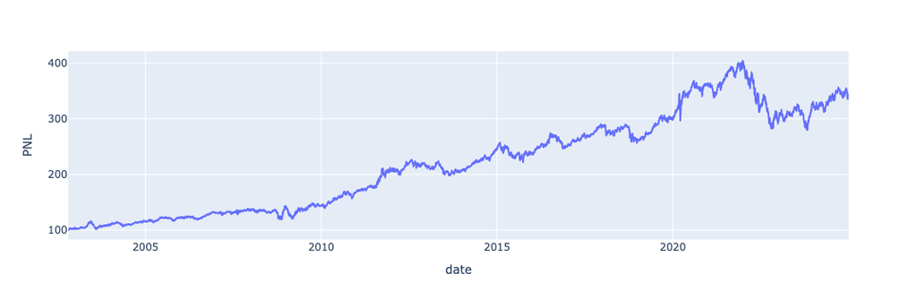

```python
TLT_SPY3_OOS.plot()
```

```python
TLT_SPY3_OOS.stats
```

|  | Returns | Volatility | Sharpe |
| --- | --- | --- | --- |
| Results | 0.082369 | 0.107901 | 0.763383 |

```python
outperformance(TLT_SPY3_OOS)
```

```
Outperformance (Sharpe): 0.320
```

```python
outperformance(TLT_SPY3_OOS, benchmark= TLT_SPY0)
```

```
Outperformance (Sharpe): 0.064
```

**Comment**

- The Sharpe here is clearly less attractive out of sample which is cause for concern.
- By virtue of being long only, this strategy will always underperform in periods of market distress as both stocks and bonds will go down

# Analysis - PCA

```python
TSV_log_ret_demeaned = (TSV_log_ret - TSV_log_ret.mean())
PCA0 = sk.decomposition.PCA(n_components= 3)
PCA0.fit(TSV_log_ret_demeaned)
PCA0.set_output(transform = "pandas")
res0 = PCA0.transform(TSV_log_ret_demeaned)
```

```python
explained_var0 = pd.DataFrame(PCA0.explained_variance_ratio_)
explained_var0.index = res0.columns
explained_var0.columns = ["Explained_Variance"]
explained_var0
```

|  | Explained_Variance |
| --- | --- |
| pca0 | 0.973652 |
| pca1 | 0.016199 |
| pca2 | 0.010149 |

```python
eigen_vectors0 = pd.DataFrame(PCA0.components_)
eigen_vectors0.columns = res0.columns
eigen_vectors0
```

|  | pca0 | pca1 | pca2 |
| --- | --- | --- | --- |
| 0 | -0.119881 | 0.031893 | 0.992276 |
| 1 | -0.562822 | 0.821171 | -0.094390 |
| 2 | 0.817838 | 0.569791 | 0.080493 |

```python
PCA_Factors0 = np.exp(np.cumsum(res0))
PCA_Factors0 = PCA_Factors0 / PCA_Factors0.iloc[0,:]
PCA_Factors0.index = TSV_log_ret_demeaned.index
```

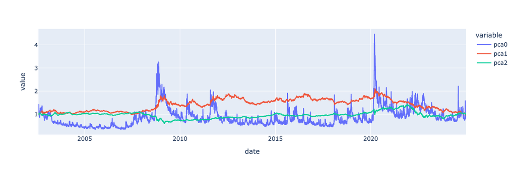

```python
fig6 = px.line(PCA_Factors0, x = PCA_Factors0.index, y = PCA_Factors0.columns)
fig6.update_layout(autosize = True)
fig6.show()
```

```python
adf_results_list: List = []
for x in range(len(res0.columns)):
    adf_results_list.append(sm.tsa.adfuller(res0.iloc[:,x]))

adf_results = pd.DataFrame(adf_results_list, index = res0.columns )
adf_results = adf_results[[0,2]]
adf_results.columns = ["T-statistic", "lag used"]
adf_results
```

|  | T-statistic | lag used |
| --- | --- | --- |
| pca0 | -29.841186 | 8 |
| pca1 | -26.073277 | 8 |
| pca2 | -77.891742 | 0 |

**Comment**

- Looking at the PCA factors it seems pretty that pca0 is simply capturing the variance (or volaility) from the VIX

```python
PCA1 = sk.decomposition.PCA(n_components= 2)
PCA1.fit(TSV_log_ret_demeaned.iloc[:,:2])
PCA1.set_output(transform = "pandas")
res1 = PCA1.transform(TSV_log_ret_demeaned.iloc[:,:2])
```

```python
explained_var1 = pd.DataFrame(PCA1.explained_variance_ratio_)
explained_var1.index = res1.columns
explained_var1.columns = ["Explained_Variance"]
explained_var1
```

|  | Explained_Variance |
| --- | --- |
| pca0 | 0.704377 |
| pca1 | 0.295623 |

```python
eigen_vectors1 = pd.DataFrame(PCA1.components_)
eigen_vectors1.columns = res1.columns
eigen_vectors1
```

|  | pca0 | pca1 |
| --- | --- | --- |
| 0 | 0.904657 | -0.426140 |
| 1 | 0.426140 | 0.904657 |

```python
PCA_Factors1 = np.exp(np.cumsum(res1))
PCA_Factors1 = PCA_Factors1 / PCA_Factors1.iloc[0,:]
PCA_Factors1.index = TSV_log_ret_demeaned.index
```

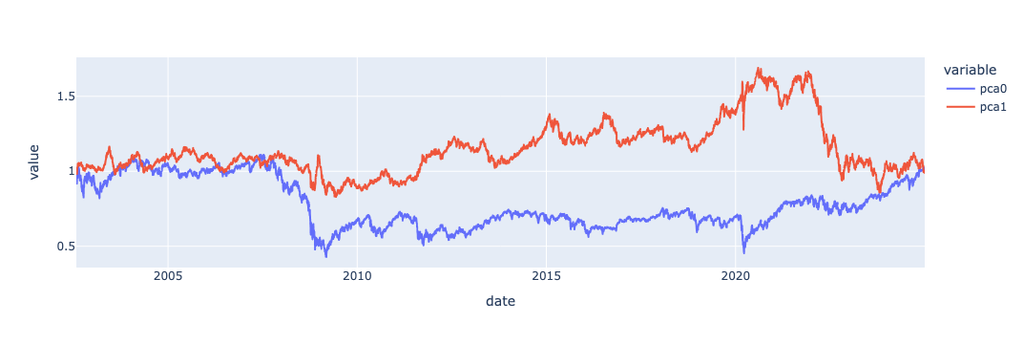

```python
fig7 = px.line(PCA_Factors1, x = PCA_Factors1.index, y = PCA_Factors1.columns)
fig7.update_layout(autosize = True)
fig7.show()
```

```python
adf_results_list: List = []
for x in range(len(res1.columns)):
    adf_results_list.append(sm.tsa.adfuller(res1.iloc[:,x]))


adf_results = pd.DataFrame(adf_results_list, index = res1.columns )
adf_results = adf_results[[0,2]]
adf_results.columns = ["T-statistic", "lag used"]
adf_results
```

|  | T-statistic | lag used |
| --- | --- | --- |
| pca0 | -19.444369 | 15 |
| pca1 | -55.774543 | 1 |

# Long short strategy - PCA mean reversion + T-statistic weightings

```python
TSVF0 = TSV.merge(PCA_Factors0, left_index= True, right_index = True)
TSVF1 = TSV.merge(PCA_Factors1, left_index= True, right_index = True)
```

```python
train_TSVF0 = TSVF0.iloc[:int(len(TSVF0)/2)]
train_TSVF1 = TSVF0.iloc[:int(len(TSVF0)/2)]
```

```python
def TLT_SPY_4(tick, securities: List = ["SPY","TLT"], data = train_TSVF0, lookback = 180) -> Tuple[int, Dict]:
    index_loc_tic: int = data.index.get_loc(tick)
    lb_window = data.iloc[index_loc_tic-lookback:index_loc_tic]

    lb_window1 = lb_window[securities + ["VIX"]]
    rolling_mean = lb_window.mean()

    lb_log_ret = (np.log(lb_window1)-np.log(lb_window1.shift(1))).dropna(how = "any")

    reg_model = sm.regression.linear_model.OLS(lb_log_ret.SPY, lb_log_ret[["TLT","VIX"]])
    reg_results = reg_model.fit()

    TLT_coef: float = reg_results.tvalues.loc["TLT"]

    SPY_w = 1/(1+abs(TLT_coef))
    TLT_w = 1 - SPY_w


    if lb_window.pca2.iloc[-1] >= rolling_mean.pca2:
        sig: tuple = (-SPY_w,-TLT_w)
    elif lb_window.pca2.iloc[-1] < rolling_mean.pca2:
        sig: tuple = (SPY_w,TLT_w)
    else:
        sig = (0,0)


    return (sig, {"add_data":{"rolling_mean": rolling_mean}})
```

```python
TLT_SPY4: Backtest = Backtest(name= "PCA long-short - mean-reversion", data = train_TSVF0)
TLT_SPY4.securities = ["SPY", "TLT"]
TLT_SPY4.assign_rebal_attr(fixed_ticks=31)
TLT_SPY4.assign_signals(trading_signal= TLT_SPY_4)
TLT_SPY4.lookback_window = 60
```

```python
TLT_SPY4.calculate()
```

| date | SPY | TLT | VIX | pca0 | pca1 | pca2 | PNL | SPY holdings | TLT holdings | SPY weights | TLT weights | Costs | Add_data |
| --- | --- | --- | --- | --- | --- | --- | --- | --- | --- | --- | --- | --- | --- |
| 2002-10-24 | 88.360001 | 85.070000 | 34.029999 | 1.076366 | 1.047775 | 0.980726 | 100.000000 | 0.264223 | 0.901061 | 0.233468 | 0.766532 | NaN | [{'add_data': {'rolling_mean': SPY 88.2131... |
| 2002-10-25 | 90.199997 | 85.379997 | 30.000000 | 0.947726 | 1.051396 | 0.989112 | 100.765496 | 0.264223 | 0.901061 | 0.233468 | 0.766532 | 0.0 | NaN |
| 2002-10-28 | 89.610001 | 85.260002 | 31.070000 | 0.982135 | 1.050761 | 0.985542 | 100.501483 | 0.264223 | 0.901061 | 0.233468 | 0.766532 | 0.0 | NaN |
| 2002-10-29 | 88.570000 | 86.370003 | 32.270000 | 1.021768 | 1.065342 | 0.986139 | 101.226868 | 0.264223 | 0.901061 | 0.233468 | 0.766532 | 0.0 | NaN |
| 2002-10-30 | 89.430000 | 86.339996 | 31.230000 | 0.988077 | 1.062718 | 0.990883 | 101.427063 | 0.264223 | 0.901061 | 0.233468 | 0.766532 | 0.0 | NaN |
| ... | ... | ... | ... | ... | ... | ... | ... | ... | ... | ... | ... | ... | ... |
| 2013-10-08 | 165.479996 | 106.169998 | 20.340000 | 0.903301 | 1.463159 | 0.851235 | 190.544026 | 0.860338 | 0.454889 | 0.749718 | 0.250282 | 0.0 | NaN |
| 2013-10-09 | 165.600006 | 105.320000 | 19.600000 | 0.870515 | 1.458272 | 0.845096 | 190.260621 | -0.477420 | -1.050585 | -0.414620 | -0.585380 | 0.0 | [{'add_data': {'rolling_mean': SPY 168.175... |
| 2013-10-10 | 169.169998 | 105.489998 | 16.480000 | 0.731197 | 1.466830 | 0.848600 | 188.377639 | -0.477420 | -1.050585 | -0.414620 | -0.585380 | 0.0 | NaN |
| 2013-10-11 | 170.259995 | 105.459999 | 15.720000 | 0.697290 | 1.467966 | 0.849468 | 187.888769 | -0.477420 | -1.050585 | -0.414620 | -0.585380 | 0.0 | NaN |
| 2013-10-14 | 170.940002 | 104.610001 | 16.070000 | 0.712274 | 1.452194 | 0.849598 | 188.457115 | -0.477420 | -1.050585 | -0.414620 | -0.585380 | 0.0 | NaN |

2762 rows × 13 columns

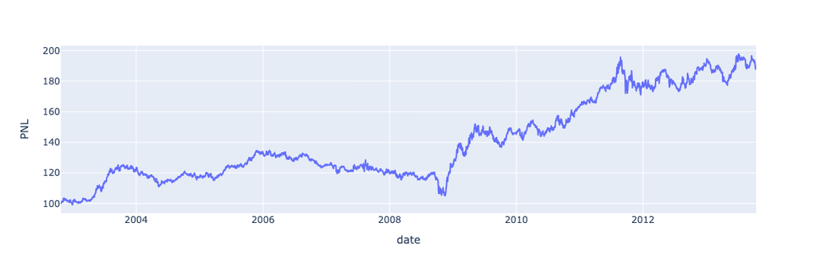

```python
TLT_SPY4.plot()
```

```python
TLT_SPY4.stats
```

|  | Returns | Volatility | Sharpe |
| --- | --- | --- | --- |
| Results | 0.08735 | 0.105777 | 0.825798 |

```python
outperformance(TLT_SPY4)
```

```
Outperformance (Sharpe): 0.382
```

# Long short strategy - PCA mean reversion (bands)

Calculate confidence interval and trade if PCA is outside of bollinger band - towards mean

```python
def TLT_SPY_5(tick, securities: List = ["SPY","TLT"], data = train_TSVF0, lookback = 180) -> Tuple[int, Dict]:
    index_loc_tic: int = data.index.get_loc(tick)
    lb_window = data.iloc[index_loc_tic-lookback:index_loc_tic]

    lb_window1 = lb_window[securities + ["VIX"]]
    rolling_mean = lb_window.mean()

    lb_log_ret = (np.log(lb_window1)-np.log(lb_window1.shift(1))).dropna(how = "any")

    reg_model = sm.regression.linear_model.OLS(lb_log_ret.SPY, lb_log_ret[["TLT","VIX"]])
    reg_results = reg_model.fit()

    TLT_coef: float = reg_results.tvalues.loc["TLT"]

    SPY_w = 1/(1+abs(TLT_coef))
    TLT_w = 1 - SPY_w

    k = sci.stats.t.ppf(0.975, lookback-1)


    upper_bound =  rolling_mean.pca2 + (k * lb_window.pca2.std() / np.sqrt(lookback-1))
    lower_bound = rolling_mean.pca2 - (k * (lb_window.pca2.std() / np.sqrt(lookback-1)))


    if lb_window.pca2.iloc[-1]  >= upper_bound:
        sig: tuple = (-SPY_w,-TLT_w)
    elif lb_window.pca2.iloc[-1] < lower_bound:
        sig: tuple = (SPY_w,TLT_w)
    else:
        sig = (0,0)


    return (sig, {"add_data":{"rolling_mean": rolling_mean}})
```

```python
TLT_SPY5: Backtest = Backtest(name= "PCA long-short - Mean-reversion", data = train_TSVF0)
TLT_SPY5.securities = ["SPY", "TLT"]
TLT_SPY5.assign_rebal_attr(fixed_ticks=31)
TLT_SPY5.assign_signals(trading_signal= TLT_SPY_5)
TLT_SPY5.lookback_window = 60
```

```python
TLT_SPY5.calculate()
```

| date | SPY | TLT | VIX | pca0 | pca1 | pca2 | PNL | SPY holdings | TLT holdings | SPY weights | TLT weights | Costs | Add_data |
| --- | --- | --- | --- | --- | --- | --- | --- | --- | --- | --- | --- | --- | --- |
| 2002-10-24 | 88.360001 | 85.070000 | 34.029999 | 1.076366 | 1.047775 | 0.980726 | 100.000000 | 0.264223 | 0.901061 | 0.233468 | 0.766532 | NaN | [{'add_data': {'rolling_mean': SPY 88.2131... |
| 2002-10-25 | 90.199997 | 85.379997 | 30.000000 | 0.947726 | 1.051396 | 0.989112 | 100.765496 | 0.264223 | 0.901061 | 0.233468 | 0.766532 | 0.0 | NaN |
| 2002-10-28 | 89.610001 | 85.260002 | 31.070000 | 0.982135 | 1.050761 | 0.985542 | 100.501483 | 0.264223 | 0.901061 | 0.233468 | 0.766532 | 0.0 | NaN |
| 2002-10-29 | 88.570000 | 86.370003 | 32.270000 | 1.021768 | 1.065342 | 0.986139 | 101.226868 | 0.264223 | 0.901061 | 0.233468 | 0.766532 | 0.0 | NaN |
| 2002-10-30 | 89.430000 | 86.339996 | 31.230000 | 0.988077 | 1.062718 | 0.990883 | 101.427063 | 0.264223 | 0.901061 | 0.233468 | 0.766532 | 0.0 | NaN |
| ... | ... | ... | ... | ... | ... | ... | ... | ... | ... | ... | ... | ... | ... |
| 2013-10-08 | 165.479996 | 106.169998 | 20.340000 | 0.903301 | 1.463159 | 0.851235 | 186.376738 | 0.841522 | 0.444940 | 0.749718 | 0.250282 | 0.0 | NaN |
| 2013-10-09 | 165.600006 | 105.320000 | 19.600000 | 0.870515 | 1.458272 | 0.845096 | 186.099531 | -0.466978 | -1.027608 | -0.414620 | -0.585380 | 0.0 | [{'add_data': {'rolling_mean': SPY 168.175... |
| 2013-10-10 | 169.169998 | 105.489998 | 16.480000 | 0.731197 | 1.466830 | 0.848600 | 184.257730 | -0.466978 | -1.027608 | -0.414620 | -0.585380 | 0.0 | NaN |
| 2013-10-11 | 170.259995 | 105.459999 | 15.720000 | 0.697290 | 1.467966 | 0.849468 | 183.779552 | -0.466978 | -1.027608 | -0.414620 | -0.585380 | 0.0 | NaN |
| 2013-10-14 | 170.940002 | 104.610001 | 16.070000 | 0.712274 | 1.452194 | 0.849598 | 184.335468 | -0.466978 | -1.027608 | -0.414620 | -0.585380 | 0.0 | NaN |

2762 rows × 13 columns

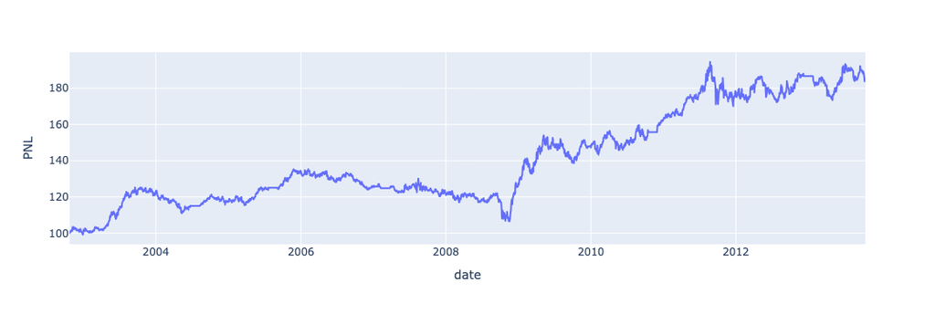

```python
TLT_SPY5.plot()
```

```python
TLT_SPY5.stats
```

|  | Returns | Volatility | Sharpe |
| --- | --- | --- | --- |
| Results | 0.084177 | 0.103212 | 0.815581 |

```python
outperformance(TLT_SPY5)
```

```
Outperformance (Sharpe): 0.372
```

**Next steps**

- Look at PNL attributions between the two assets to get a better idea of when each strategy performs well
- The relationship between bonds and equities is attenuated by many other factors (e.g Inflation, interest rates, Economic growth), so looking at macro data or approaches to identify regimes (Hidden Markov Models) may be interesting
- Investigate pairs trading between TLT and SPY (co-integration tests)
- Look at properly evaluating the role of volatility (both change and level)